# GSS challange More Data

Jesse Hook

Nov 24 2026

# Introduction

Is attitude toward capitol punishment (cappun) independent of race (race)? If not, then whose view differs from whom??

Data from GSS 2016.

$H_0$ : Yes attitude towards capitol punishment is independent of race. In other words there’s no difference… (-_-)

$H_A$ : No, attitude towards capitol punishment is NOT independent of race!!! AKA there is a difference in views!

# Methods

Lets use the freaking Cat~Cat file for this since race and capital punishment are categorical, right?!

# Results

## Descriptive Results

### Graphical Descriptive Results

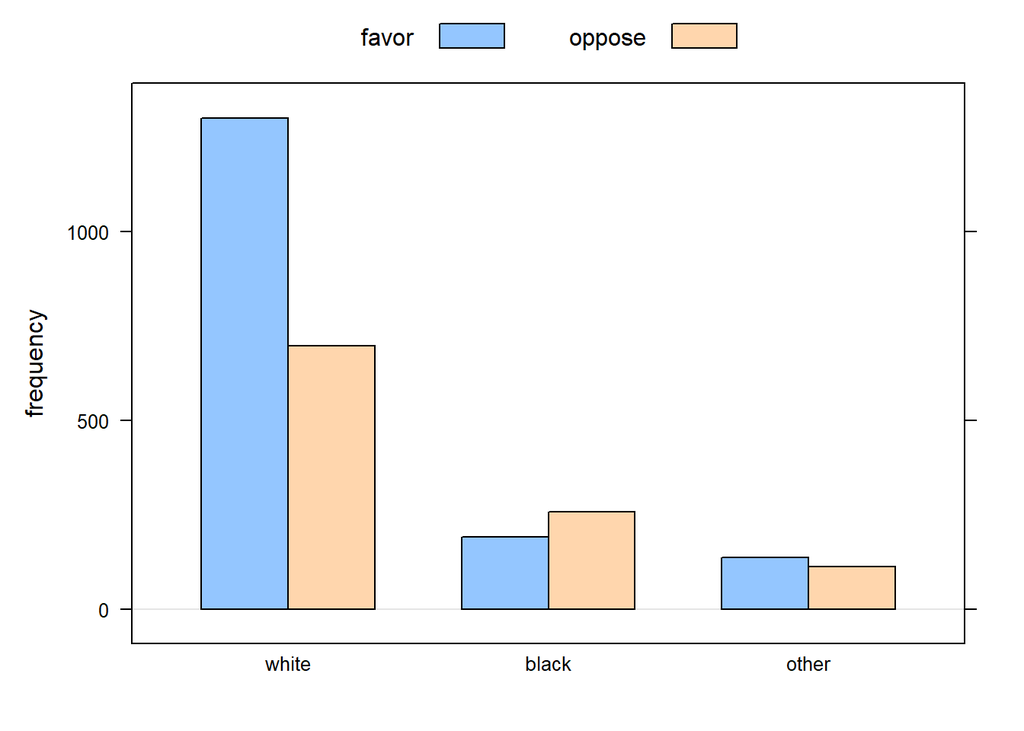

```r
barchartGC(~race + cappun,data=mydata)
```

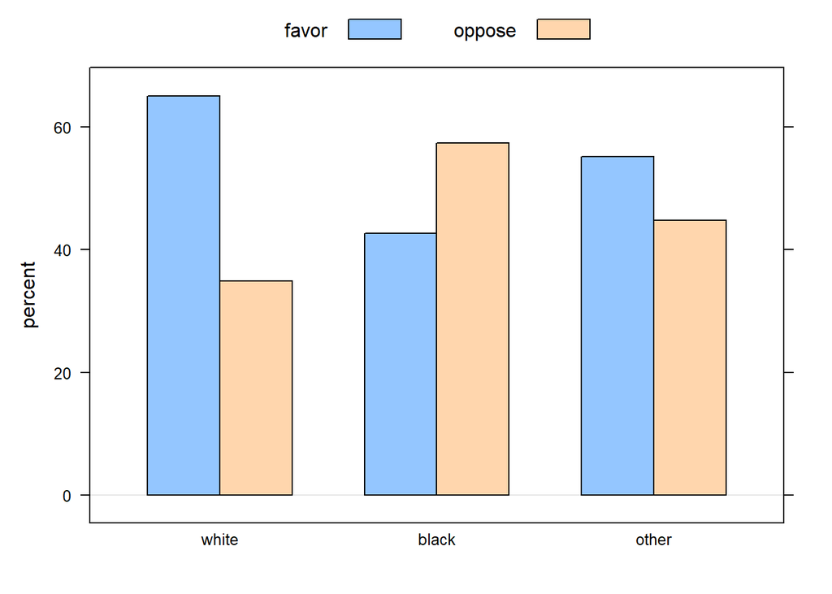

```r
barchartGC(~race + cappun,data=mydata, type="percent")
```

These graphs suggest that white people have a higher percentage of being in favour of capital punishment, being the highest percentage out of the three race options, followed by “other” and lastly black people. This is from the second graph, assuming the first one factors in the population of said races.

## Now with The Most data (fewer variables gives more data points)

### Numerical Descriptive Results

```r
table1 <- xtabs(~race + cappun, data=mydata)
rowPerc(table1)
```

```
##        cappun
## race     favor oppose  Total
##   white  65.10  34.90 100.00
##   black  42.63  57.37 100.00
##   other  55.20  44.80 100.00
```

```r
colPerc(table1)
```

```
##        cappun
## race     favor oppose
##   white  79.80  65.38
##   black  11.72  24.11
##   other   8.47  10.51
##   Total 100.00 100.00
```

From these results we can see that white people do indeed have a higher percentage of favouring capital punishment when compared with the other races. Roughly 65% of white people favour capital punishment, whereas roughly 43% of black people favour it, and finally roughly 55% of people in the “other” race category favour it. Overall these results suggest that white people have the smallest percentage of being opposed to it.

## Inferential Results

```r
fisherXY(mydata$race,mydata$cappun,confL=0.05)
```

```
##
## contingency table:
##        y
## x       favor oppose
##   white  1300    697
##   black   191    257
##   other   138    112
##
## ***All 2X2 tests****
##
## [1] "white" "black"
## [1] "favor"  "oppose"
##        y
## x       favor oppose
##   white  1300    697
##   black   191    257
##
##  Fisher's Exact Test for Count Data
##
## data:  fTempTable
## p-value < 2.2e-16
## alternative hypothesis: true odds ratio is not equal to 1
## 5 percent confidence interval:
##  2.477294 2.539321
## sample estimates:
## odds ratio
##   2.508637
##
##
## [1] "white" "other"
## [1] "favor"  "oppose"
##        y
## x       favor oppose
##   white  1300    697
##   other   138    112
##
##  Fisher's Exact Test for Count Data
##
## data:  fTempTable
## p-value = 0.002607
```

[output cut: 10 more lines]

```
##        y
## x       favor oppose
##   black   191    257
##   other   138    112
##
##  Fisher's Exact Test for Count Data
##
## data:  fTempTable
## p-value = 0.001564
## alternative hypothesis: true odds ratio is not equal to 1
## 5 percent confidence interval:
##  0.5902965 0.6175220
## sample estimates:
## odds ratio
##  0.6036291
```

The fisherXY test shows that all races have a difference in favouring/not favouring capital punishment, as each one has a p value less than 0.05. So we can reject the null. They also each have different odds ratios.

# Discussion and Conclusion

Original question: Is attitude toward capitol punishment (cappun) independent of race (race)? If not, then whose view differs from whom??

Based on the fisherXY test which shows that each race has a differing relationship to favouring or not favouring capital punishment, we can reject the null that there is no difference between races and capital punishment. Each race has a difference relationship with these stats, with the following p values for the different races: 2.2e-16, 0.002607, and 0.001564. All of these are less than 0.05, which is why he can confidently reject the null and finish this crap up!!